# Plane Crash Analysis

By Angela Escobar

This project analyzes a database that records aviation accidents during the 20th and 21st centuries. The purpose is to gain insights into the nature of these accidents and the evolution of aviation progress over the years.

### **Ask**

What conclusions and insights can we draw about the history of aviation and its recordkeeping?

### **Prepare**

For this analysis project, the necessary metrics were identified in the preparation phase. Following this, the database was located, downloaded, and securely and systematically organized on the computer. Additionally, version control using Git was established to ensure the security of the information.

### **Process**

This database required significant cleaning as the information had not been stored in the most organized manner. Some of the most important tasks in this stage included correcting the data type of each column, splitting column contents for better information handling, creating new columns and additional dataframes for improved organization and management of information. The activities carried out are described in the list below; more detailed information can be found in the project code.

- Check info type of each column
- Correct date column
- Convert the “date” column to the desired format
- Change the date format to “yyyy/mm/dd”
- Change the data type of the “date” column to Date
- Correct time column
- Correct flight column type
- Remove non-numeric characters from the “flight_no” column
- Convert the “flight_no” column to integers
- Split the “route” column into two separate columns by “-”(origin-destination)
- Create a new column “fatalities_number” containing the first two characters from the “fatalities” column
- Convert the “fatalities_number” column to integers
- Create column “year”
- Verify amount of operators
- Create dataframe of counts grouped by state (for US)
- Create dataframe of counts grouped by country
- To sum up the dataframes from the US and the rest of the world.

### **Analysis**

After organizing the database in a clearer manner, the next step involved reviewing the insights that could be derived from the provided information. The specific points for analysis were defined as follows:

- Evolution of the number of plane crashes over the decades.
- Evolution of deaths caused by plane crashes over the decades.
- Total number of plane crashes by country.
- Analysis of countries with the highest number of air accidents.
- Aircraft with the most air accidents.
- Tracking the performance of aircraft with the most air accidents over the years.

### **Share**

*Following the completion of the necessary procedures for the analysis, the ensuing results were obtained, providing insights into the dataset under examination:*

Around the 1920s, accidents were few, but they began to increase as aviation became more popular.

By the late 1940s, when commercial flights started gaining more popularity, the most significant increase in air accidents was observed.

The decade with the highest number of air accidents was the 1970s.

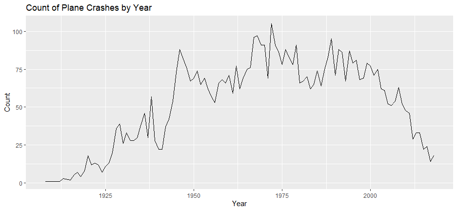

The number of deaths also remained under control during the 1920s. However, by the late 1940s, there was a sharp rise in deaths caused by plane crashes. This was also due to the widespread use of commercial flights. Similarly, since the 1980s, the number of deaths from plane crashes has been decreasing due to technological advancements, increased knowledge, and safety measures.

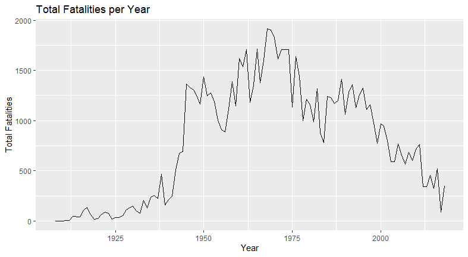

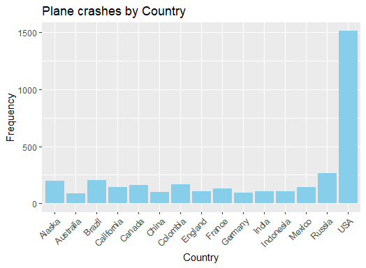

These were the 5 aircraft that appeared most frequently in the records of air accidents. It’s important to consider the timeframe in which these aircraft were used and, consequently, the technology implemented for their operation.

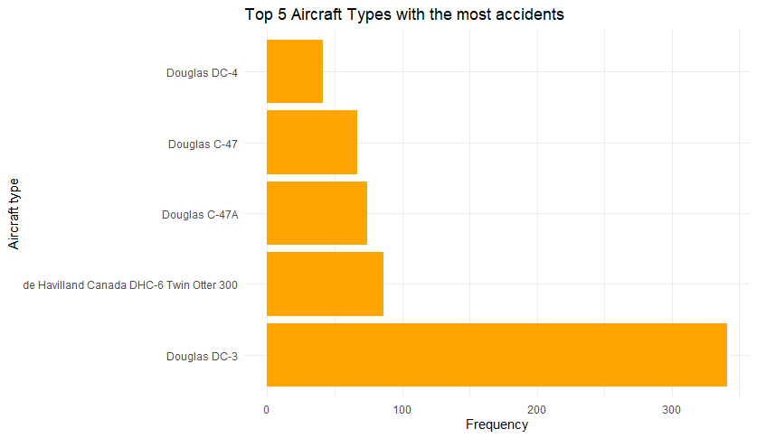

Another aircraft with numerous accidents during that period was the “Douglas C47”; however, it did not have even half the number of accidents as the “Douglas DC3.” Currently, the aircraft model with the highest number of accidents is the “de Havilland Canada DHC-6 Twin Otter 300,” which is a small aircraft mainly used for private flights with a low number of passengers.

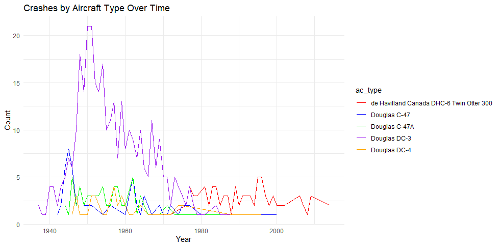

### **Act**

**__________________END OF STUDY CASE_______________**